# R Notebook

# Trait Normalisation

Fundamentally, GWAS is just a linear model. Linear models assume that the response trait is approximately normally distributed. This is an important assumption - it dictates how wide the confidence intervals are around the final estimates (i.e. how certain it is about those estimates). Wildly skewed data will likely led to wildly uncertain estimates, and thus probably non-significant results.

Plan:

1. Load the combined trait file
2. Visualise the distribution of each trait
3. For those that are mildly skewed, perform a mild transformation (e.g. square root or log transform)
4. For the rest, we will try quantile normalisation
5. Failing either of the above, we will resort to using the boxcox transformation

**NOTE:** This is the really important stuff :) This is the stuff that you want to get right before the GWAS. It’ll take some thought, and I don’t intend to (semi)automoate this anytime soon!

## Load and visualise traits

```r
setwd("c:/Users/Macknight Lab User/Documents/GitHub/GWASPipeline/Sandpit/TraitWrangling/")
```

```
The working directory was changed to c:/Users/Macknight Lab User/Documents/GitHub/GWASPipeline/Sandpit/TraitWrangling inside a notebook chunk. The working directory will be reset when the chunk is finished running. Use the knitr root.dir option in the setup chunk to change the the working directory …
```

```r
library(data.table)
library(ggplot2)
traits <- fread("MedicagoTraits.combined")
head(traits)
```

| FID | IID | GH2_FlDate | nodestofloweringV | NV_FTa1 | FTa1_Expn | FTa1_V_Lessexcllines | FTa2_Q_V_AA_AF | FTb1_qPCR | SOC1c | SOC1c_V |
| --- | --- | --- | --- | --- | --- | --- | --- | --- | --- | --- |
| 0 | HM001 | -6.29 | -9.0 | 0.01300 | -9.0000 | -9.0000 | -9.00000 | -9.0000 | 0.2009 | -9.0000 |
| 0 | HM002 | -3.29 | 5.5 | 0.00000 | 0.2613 | 0.2613 | -9.00000 | 0.1369 | 0.0323 | 0.2179 |
| 0 | HM003 | 2.08 | -9.0 | 0.00000 | 0.5156 | 0.5156 | 0.00194 | 0.0000 | 0.2054 | 1.0360 |
| 0 | HM004 | 1.58 | 6.0 | 0.03200 | -9.0000 | -9.0000 | -9.00000 | -9.0000 | 0.7609 | -9.0000 |
| 0 | HM005 | 2.28 | 10.5 | 0.01000 | 0.0970 | 0.0970 | -9.00000 | 0.1837 | 0.0232 | -9.0000 |
| 0 | HM006 | 2.33 | 9.0 | 0.00873 | 0.0107 | 0.0107 | -9.00000 | 0.4988 | -9.0000 | 0.0476 |

Create histograms for each trait.

```r
by_trait <- reshape2::melt(traits, id.vars = c("FID", "IID"))
head(by_trait)
```

| FID | IID | variable | value |
| --- | --- | --- | --- |
| 0 | HM001 | GH2_FlDate | -6.29 |
| 0 | HM002 | GH2_FlDate | -3.29 |
| 0 | HM003 | GH2_FlDate | 2.08 |
| 0 | HM004 | GH2_FlDate | 1.58 |
| 0 | HM005 | GH2_FlDate | 2.28 |
| 0 | HM006 | GH2_FlDate | 2.33 |

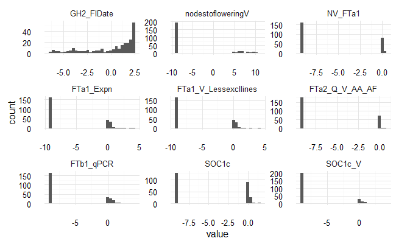

```r
ggplot(by_trait, aes(x = value)) +
    geom_histogram() +
    facet_wrap(~ variable, scales="free") +
    theme_minimal()
```

There are a bunch of missing values in the traits :) We knew this, I just forgot. Let’s visualise these again without these missing values, so that we can see what the actual data looks like.

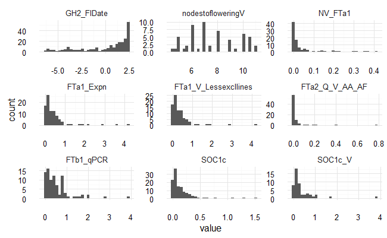

```r
ggplot(by_trait[value != -9], aes(x = value)) +
    geom_histogram() +
    facet_wrap(~ variable, scales = "free") +
    theme_minimal()
```

About the traits:

- GH2_FlDate: heavily left skewed, but there is a good number of observations across the full range.
- nodestofloweringV: this look really good - not going to do anything with this one
- the rest are all heavily right skewed - with some serious outliers. Will try quantile normalisation on these, removing outliers if necessary

## Transform

```r
by_trait[value != -9, log_value := log10(value + 7)]
```

| FID | IID | variable | value | log_value |
| --- | --- | --- | --- | --- |
| 0 | HM001 | GH2_FlDate | -6.290000 | -0.148741651 |
| 0 | HM002 | GH2_FlDate | -3.290000 | 0.569373910 |
| 0 | HM003 | GH2_FlDate | 2.080000 | 0.958085849 |
| 0 | HM004 | GH2_FlDate | 1.580000 | 0.933487288 |
| 0 | HM005 | GH2_FlDate | 2.280000 | 0.967547976 |
| 0 | HM006 | GH2_FlDate | 2.330000 | 0.969881644 |
| 0 | HM007 | GH2_FlDate | 2.390000 | 0.972665592 |
| 0 | HM008 | GH2_FlDate | 2.450000 | 0.975431809 |
| 0 | HM009 | GH2_FlDate | -4.670000 | 0.367355921 |
| 0 | HM010 | GH2_FlDate | 0.080000 | 0.850033258 |

[output cut: 990 more lines]

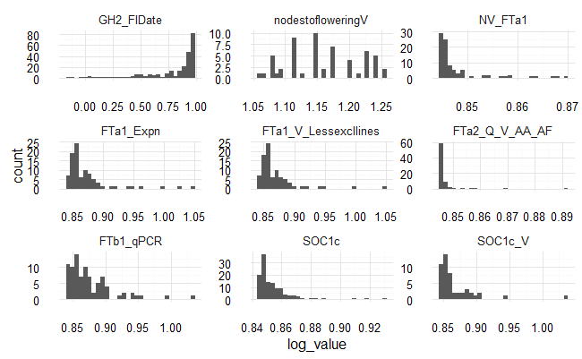

```r
ggplot(by_trait[value != -9], aes(x = log_value)) +
    geom_histogram() +
    facet_wrap(~ variable, scales = "free") +
    theme_minimal()
```

And now, let’s visualise these to see how they look:

[figure not shown]

This is looking amazing! let’s have a good look at the data though and make sure it makes sense:

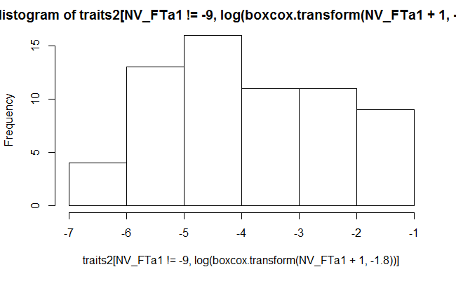

| FID | IID | GH2_FlDate | nodestofloweringV | NV_FTa1 | FTa1_Expn | FTa1_V_Lessexcllines | FTa2_Q_V_AA_AF | FTb1_qPCR | SOC1c | SOC1c_V |
| --- | --- | --- | --- | --- | --- | --- | --- | --- | --- | --- |
| 0 | HM001 | NaN | -9.0 | -4.360873 | -9.000000e+00 | -9.000000e+00 | -9.000000 | -9.000000 | 0.20090 | -9.00000 |
| 0 | HM002 | NaN | 5.5 | -Inf | 1.556576e-01 | 1.939074e-01 | -9.000000 | 0.136900 | 0.03230 | 0.21790 |
| 0 | HM003 | -4.54100280 | -9.0 | -Inf | 2.189482e-01 | 3.036749e-01 | 0.001940 | 0.000000 | 0.20540 | 1.03600 |
| 0 | HM004 | -2.96514486 | 6.0 | -3.486025 | -9.000000e+00 | -9.000000e+00 | -9.000000 | -9.000000 | 0.76090 | -9.00000 |
| 0 | HM005 | -5.26442044 | 10.5 | -4.619091 | 7.764162e-02 | 8.604884e-02 | -9.000000 | 0.183700 | 0.02320 | -9.00000 |
| 0 | HM006 | -5.45376278 | 9.0 | -4.753152 | 1.041554e-02 | 1.055305e-02 | -9.000000 | 0.498800 | -9.00000 | 0.04760 |
| 0 | HM007 | -5.68549208 | -9.0 | -6.899218 | 3.767880e-02 | 3.954738e-02 | -9.000000 | 0.000000 | 0.00829 | -9.00000 |
| 0 | HM008 | -5.92217223 | -9.0 | -9.000000 | 1.494053e-01 | 1.842753e-01 | 0.000000 | 3.866000 | 0.14550 | -9.00000 |
| 0 | HM009 | NaN | 7.0 | -3.198779 | 1.737735e-01 | 2.229510e-01 | 0.004260 | 0.391600 | 0.14280 | 0.70490 |
| 0 | HM010 | -0.08322112 | 8.0 | -Inf | 6.296537e-02 | 6.837611e-02 | 0.000000 | 0.315700 | -9.00000 | -9.00000 |

[output cut: 240 more lines]